# Analysing and visualizing the Datasets using R MarkDown

By Akhila Kvns

16 January, 2017

# Introduction

This is an introduction to R Markdown. Here i am going to visualize the following datasets:

- ChickWeight
- Iris

## Description

**1. CHICKWEIGHT**

```r
library(datasets)
data(ChickWeight)
summary(ChickWeight)
```

```
##      weight           Time           Chick     Diet
##  Min.   : 35.0   Min.   : 0.00   13     : 12   1:220
##  1st Qu.: 63.0   1st Qu.: 4.00   9      : 12   2:120
##  Median :103.0   Median :10.00   20     : 12   3:120
##  Mean   :121.8   Mean   :10.72   10     : 12   4:118
##  3rd Qu.:163.8   3rd Qu.:16.00   17     : 12
##  Max.   :373.0   Max.   :21.00   19     : 12
##                                  (Other):506
```

```r
head(ChickWeight)
```

```
##   weight Time Chick Diet
## 1     42    0     1    1
## 2     51    2     1    1
## 3     59    4     1    1
## 4     64    6     1    1
## 5     76    8     1    1
## 6     93   10     1    1
```

**2. Iris**

Theiris dataset gives the measurements in centimeters of the variables sepal length and width and petal length and width, respectively, for 50 flowers from each of 3 species of iris. The species are Iris setosa, versicolor, and virginica.

```r
library(datasets)
data(iris)
summary(iris)
```

```
##   Sepal.Length    Sepal.Width     Petal.Length    Petal.Width
##  Min.   :4.300   Min.   :2.000   Min.   :1.000   Min.   :0.100
##  1st Qu.:5.100   1st Qu.:2.800   1st Qu.:1.600   1st Qu.:0.300
##  Median :5.800   Median :3.000   Median :4.350   Median :1.300
##  Mean   :5.843   Mean   :3.057   Mean   :3.758   Mean   :1.199
##  3rd Qu.:6.400   3rd Qu.:3.300   3rd Qu.:5.100   3rd Qu.:1.800
##  Max.   :7.900   Max.   :4.400   Max.   :6.900   Max.   :2.500
##        Species
##  setosa    :50
##  versicolor:50
##  virginica :50
##
##
##
```

```r
head(iris)
```

```
##   Sepal.Length Sepal.Width Petal.Length Petal.Width Species
## 1          5.1         3.5          1.4         0.2  setosa
## 2          4.9         3.0          1.4         0.2  setosa
## 3          4.7         3.2          1.3         0.2  setosa
## 4          4.6         3.1          1.5         0.2  setosa
## 5          5.0         3.6          1.4         0.2  setosa
## 6          5.4         3.9          1.7         0.4  setosa
```

Now we are using the following functions on the datsets.

1. plot()
2. hist()

### Plot()

- ChickWeight

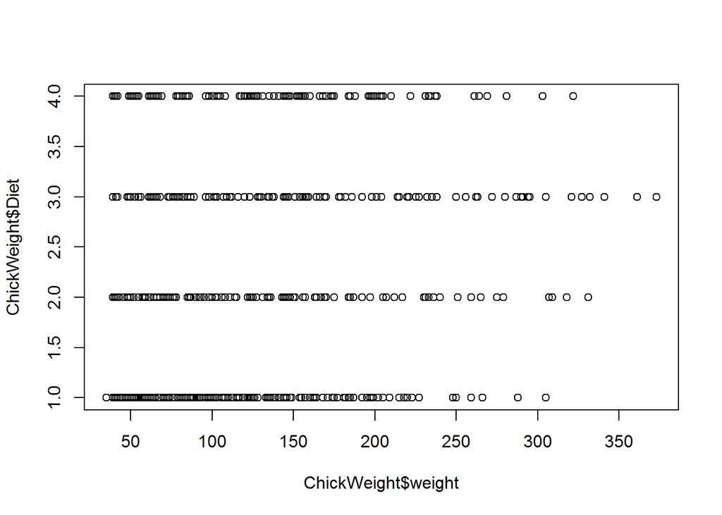

```r
plot(ChickWeight$weight , ChickWeight$Diet)
```

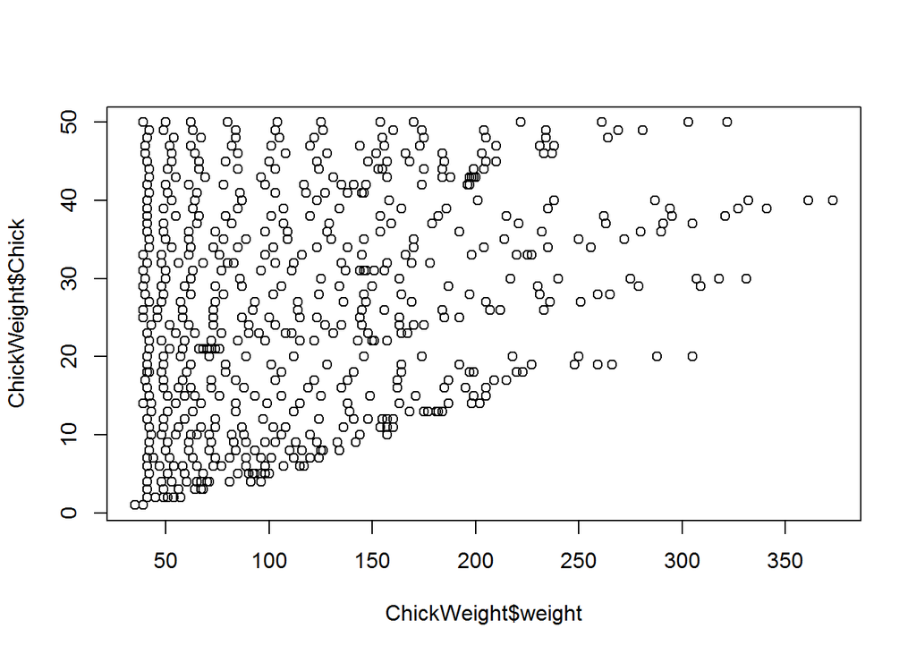

```r
plot(ChickWeight$weight , ChickWeight$Chick)
```

- Iris

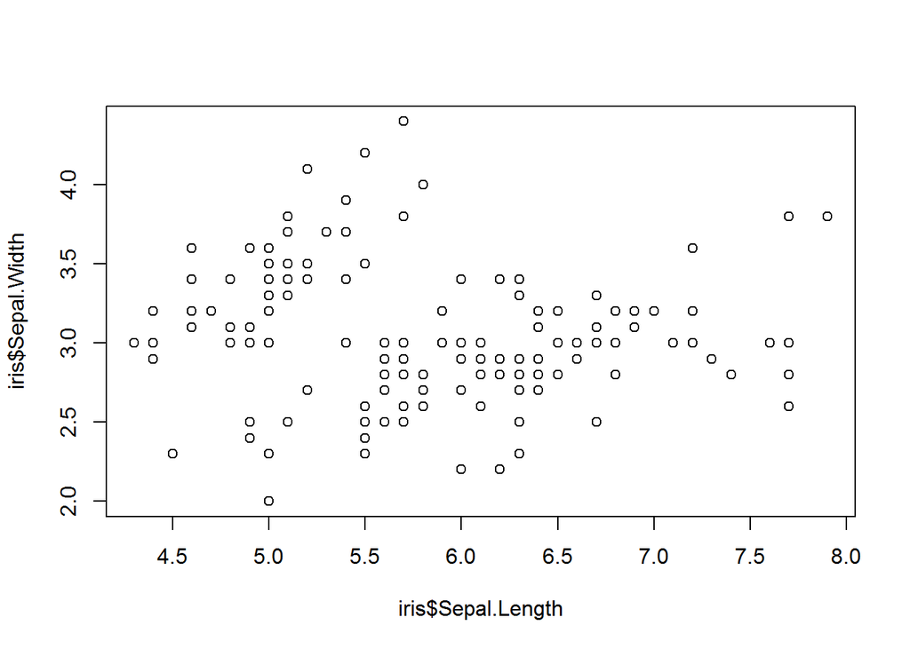

```r
plot(iris$Sepal.Length, iris$Sepal.Width)
```

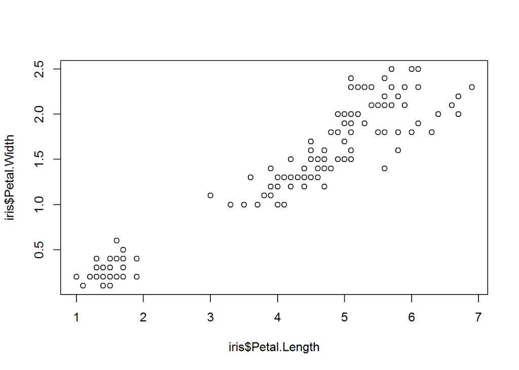

```r
plot(iris$Petal.Length, iris$Petal.Width)
```

### Hist()

- ChickWeight

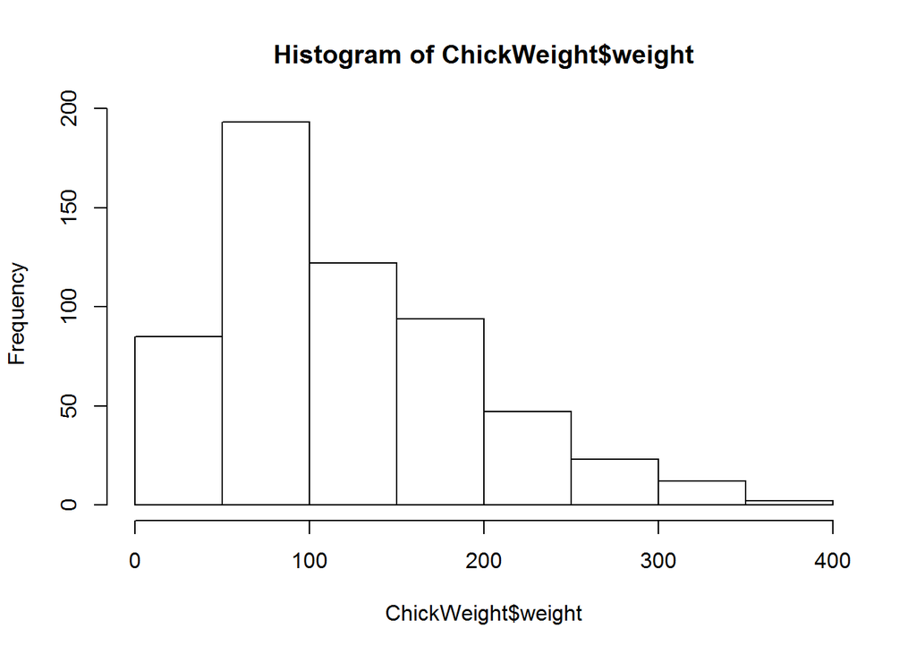

```r
hist(ChickWeight$weight)
```

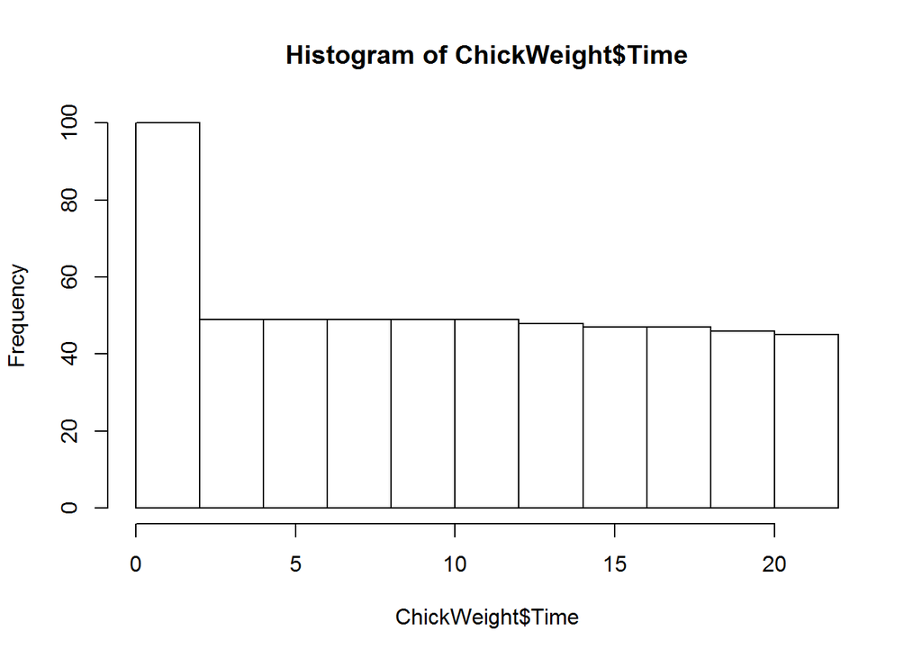

```r
hist(ChickWeight$Time)
```

- Iris

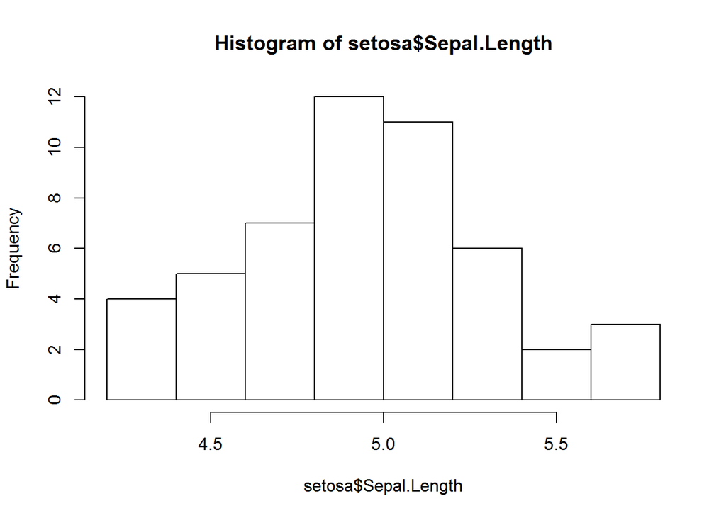

```r
iris_obs <- iris$Species == "setosa"
setosa <- iris[iris_obs,]
hist(setosa$Sepal.Length , breaks=10)
```

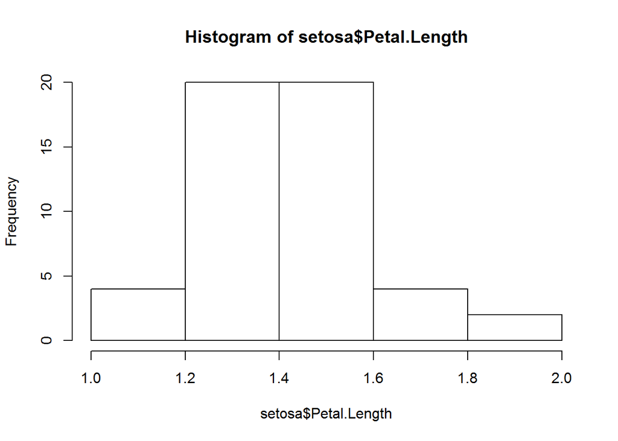

```r
hist(setosa$Petal.Length, breaks=5)
```

## Bar plot()

Here we are using bar plot to plot our datsets

- ChickWeight

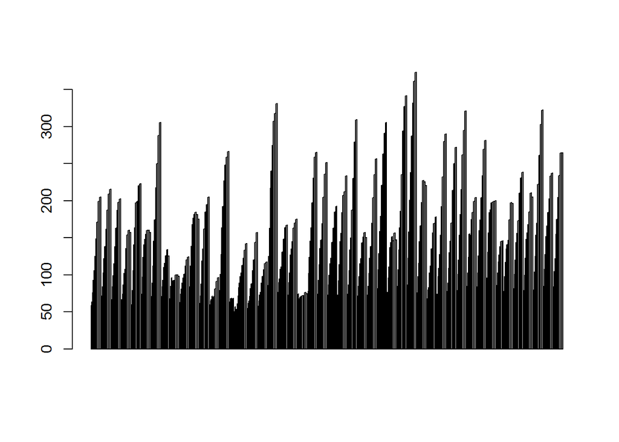

```r
barplot(ChickWeight$weight, ChickWeight$Time)
```

- Iris

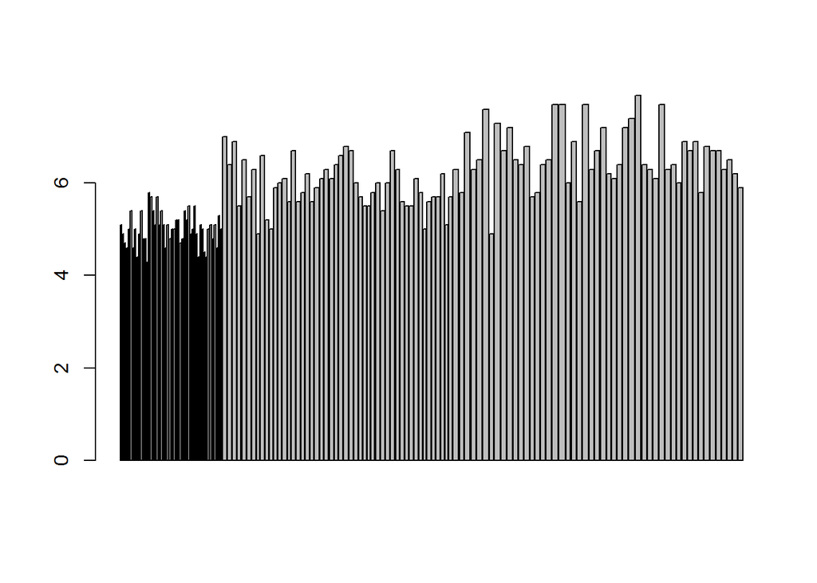

```r
barplot(iris$Sepal.Length, iris$Petal.Length)
```

## Box plot()

Here we use box plot to plot both the datasets.

1. ChickWeight

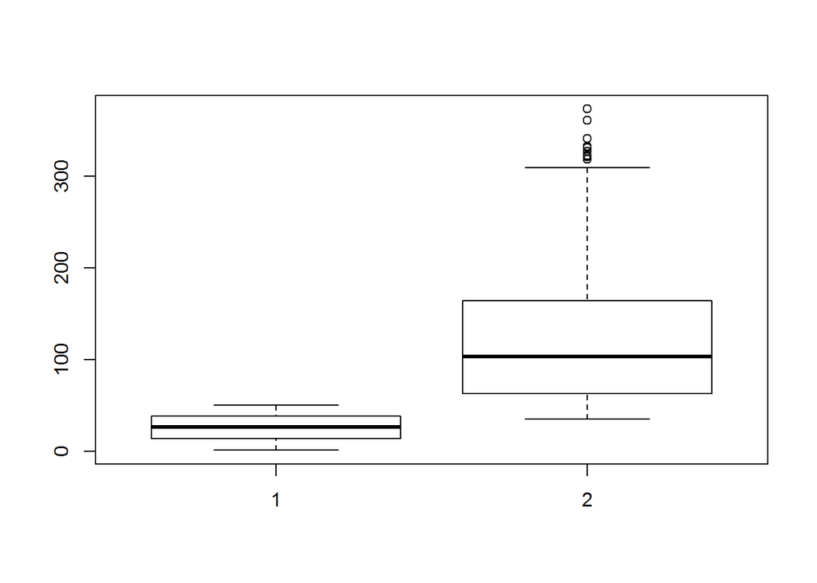

```r
boxplot(ChickWeight$Chick, ChickWeight$weight)
```

2. Iris

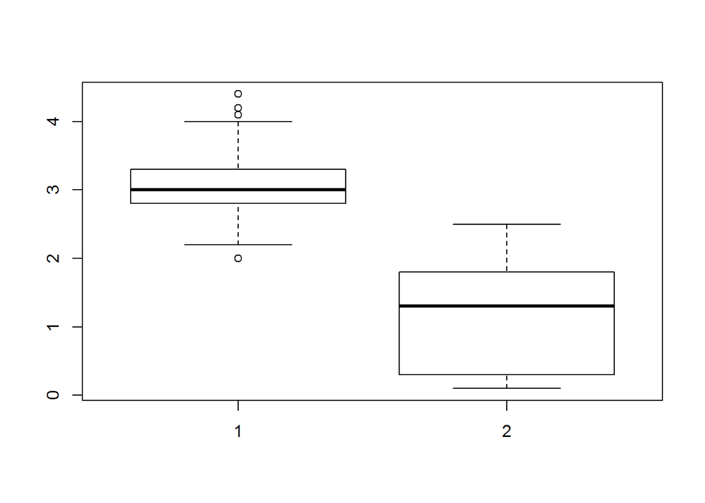

```r
boxplot(iris$Sepal.Width, iris$Petal.Width)
```